# Logbook Jasper Jonker

Jasper Jonker

2024-09-10

# Logboek Jasper Jonker

Dit is het Logboek van Jasper Jonker voor het vak 2.1.2 Genomics & Transcriptomics. Met dit vak gaan we een paper opnieuw na doen of een andere onderzoeksvraag beantwoorden met de data die gegeven is bij de paper.

Als er wordt gezegd dat het in een ander logboek staat moet je gaan kijken op de Github pagina van ons naar het gevraagde logboek.

## 09-09

We starten het onderzoek. We moeten eerst een paper vinden of verslag die genoeg meetwaarde heeft; met meerde meetwaarde onder de zelfde omstandigheden. We doen het onderzoek met vier mensen dus hebben besloten om ieder 1 onderzoek uit te kiezen. Om zeker te weten dat er 1 tussen zit die voldoet aan alle eisen die gesteld worden. En we kunnen alle onderzoeken zo verkleinen naar maar vier. Daaruit is het voor ons dan makkelijker uitkiezen.

## 10-09

Ik heb voor het volgende onderzoek gekozen: [Entinostat induces antitumor immune responses through immune editing of tumor neoantigens](https://pubmed.ncbi.nlm.nih.gov/34396985/). Het is een onderzoek dat gaat over het bestrijden van blaaskanker met behulp van specifiek soorten eiwitten. Omdat er hedendaags nog heel veel mensen dood aan gaan en ook de behandeling die ze nu gebruiken, chemotherapie, niet altijd even goed aanslaat. Dit onderzoek wordt eerst op muizen getest. Nu nog wachten op goedkeuring van de docenten.

## 11-09

Na goedkeuring is mijn tekst gekozen om mee verder te gaan in dit project. Nu gaan we bezig met het plan van aanpak. IK ga bezig met de workflow.

## 13-09 & 14-09

Bezig met de workflow en gekeken wat we uiteindelijk gaan doen.

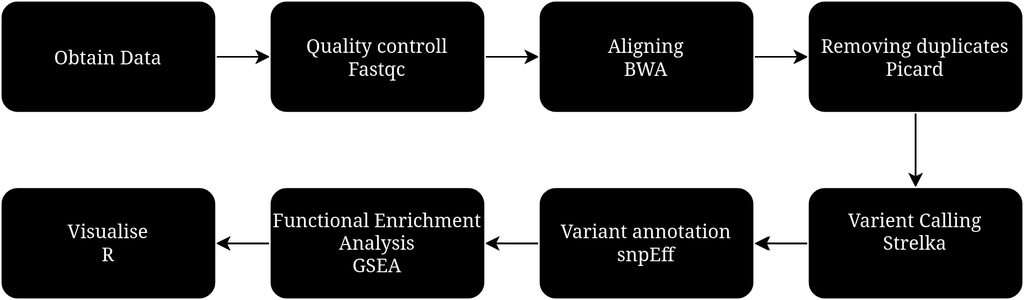

We hebben besloten om het onderzoek na te bootsen maar ook een beetje te verbreden. We gaan ook kijken naar wat de mutatie van de kanker zijn en wat voor gevolg het heeft op biologische processen verder in het lichaam. Dat lijkt ons leuker om te doen dan het onderzoek precies na te doen.

## 16-09

Het plan van aanpak gepresenteerd. In het onderzoek gebruiken ze [Genome assembly MGSCv37](https://www.ncbi.nlm.nih.gov/datasets/genome/GCF_000001635.18/) referentie genoom. We hebben na overleg met elkaar ervoor gekozen om de nieuwste te gaan gebruiken. Dat is dus [Genome assembly GRCm39](https://www.ncbi.nlm.nih.gov/datasets/genome/GCF_000001635.27/) Dit omdat dat gen het nieuwst is en ook het bekendst is. Hierdoor kan je een nieuwe ontdekking krijgen doordat er misschien fouten waren in het oude genoom en die nu verdwenen kunnen zijn. We hebben ook een taak verdeling gemaakt. Ik ga bezig met bwa omdat het mij iets moeilijks lijkt en ik mezelf wil uitdagen. BWA wordt ook veel gebruikt in de bio-informatica dus het is sowieso handig om te weten hoe het werkt. BWA vergelijkt de korte DNA- of RNA-sequenties die door een sequencer zijn gegenereerd (bijv. Illumina-reads) met een bekende referentie genoom. Het bepaalt waar die reads het beste passen in de genoom sequentie. BWA wordt vaak gebruikt in genomische studies, waaronder:

```
Variantdetectie: SNP's, indels en andere genetische variaties.
Mutatieanalyse: Bij kankeronderzoek of erfelijke ziektes.
Metagenomics: Het identificeren van micro-organismen in complexe monsters.
Transcriptomics: Het analyseren van RNA-gegevens (bijvoorbeeld splice-varianten).
```

## 17-09

Ik ga vandaag eerst testdata maken in een oefen Folder die later weer wordt verwijderd. We maken test data omdat die data kleiner is dan de normale data en daarom makkelijker te gebruiken is in onze tools zodat het niet te lang duurt. We hebben maar een bepaalde tijd en als we telkens moeten wachten op dat de tools klaar zijn en het fout kan gaan op het laatste moment, houdt je op deze manier veel belangrijke tijd over. Dit doen we even allemaal en doen het met 10000 reads omdat het ons groot genoeg lijkt. We doen het allemaal omdat het in andere onderzoeken ook gebruikt kunnen worden.

```bash
find /students/2024-2025/Thema05/BlaasKanker/fastq/ -name "*.fastq" | \
    parallel "seqkit sample -p 0.1 {} | seqkit head -n 10000 > /students/2024-2025/Thema05/BlaasKanker/oefenengroep/testdataJasper/{/}"
```

Hier ga ik ook een Fastqc maken van de oefendata zodat we dat ook allemaal even weten. Want later moeten we Fastqc bestanden maken van de data om te kijken of de data na het trimmen naar wens is met niet te veel duplicaten bijvoorbeeld en of de data wel van goede kwaliteit is.

```bash
fastqc /students/2024-2025/Thema05/BlaasKanker/oefenengroep/testdataJasper/* \
    -o /students/2024-2025/Thema05/BlaasKanker/oefenengroep/FastqcJasper/
```

Dit doe we ook voor multiqc.

```bash
multiqc /students/2024-2025/Thema05/BlaasKanker/oefenengroep/FastqcJasper/* -o /students/2024-2025/Thema05/BlaasKanker/oefenengroep/multiqcJasper/
```

Hier kunnen we makkelijk zien hoe goed de data is en of het van goede kwaliteit is. ## 18 -09

Vandaag ga ik bezig met BWA terwijl anderen bezig zijn met het trimmen. Hierdoor werken we alvast een beetje vooruit en kunnen we, als we klaar zijn met trimmen, in 1 keer door. Ik doe het eerst simpel en in een testing tools map zodat het duidelijk is voor iedereen die het dan leest en ik het ook goed kan uitleggen. We gebruiken de versie 0.7.17-r1188. In de paper gebruiken ze version 0.7.4. Dus dit kan verschil opleveren.

```bash
# hier maken er de van de refence genome een index file zodat de tool sneller gaat.
bwa index /students/2024-2025/Thema05/BlaasKanker/realreferenceGenome/ncbi_dataset/data/GCF_000001635.27/GCF_000001635.27_GRCm39_genomic.fna
# hier starten we het mappen en noemen het output.sam op de teastdata
bwa mem -t 8  SRR14870694_1.fastq SRR14870694_2.fastq > outputtest.sam
# hier veranderen we het sam file naar een bam file omdat het minder ruimte in neemt
samtools view -b outputtest.sam > output.bam
# Nu gaan we sorteren op coördinaten
samtools sort -o output.sorted.bam outputtest.bam

samtools index output.sorted.bam
```

Voor deze tool te begrijpen heb ik de volgende tutorial gebruikt om het te begrijpen en uiteindelijk te kunnen toepassen op onze eigen data : [How I perform Genome Mapping using BWA](https://www.youtube.com/watch?v=1wcFavYt6uU)